# EasyVisa Project

## Exploratory Data Analysis (EDA) after Data Preprocessing

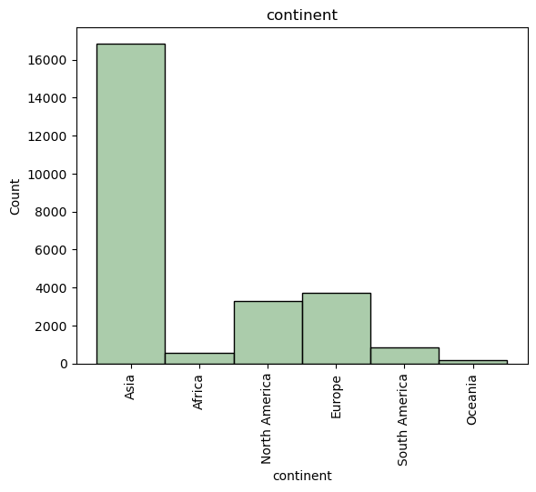

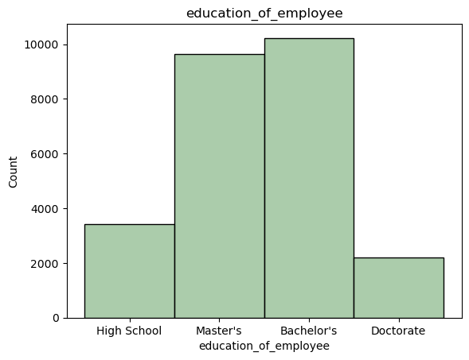

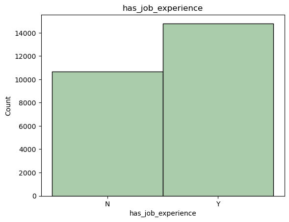

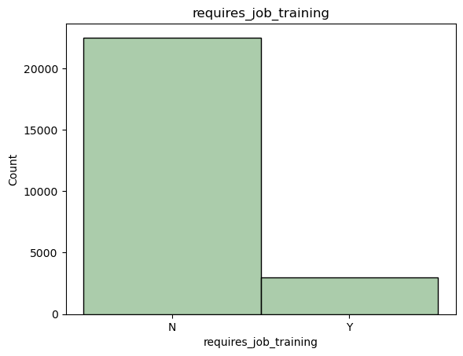

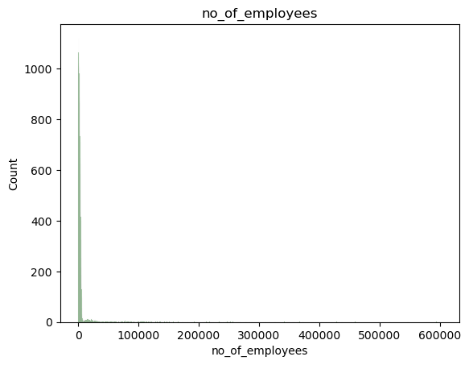

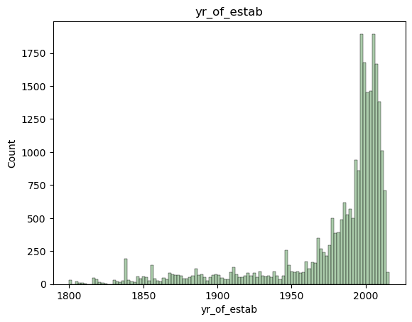

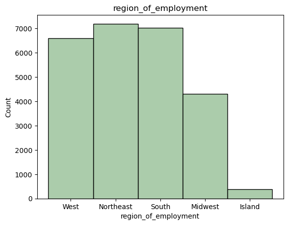

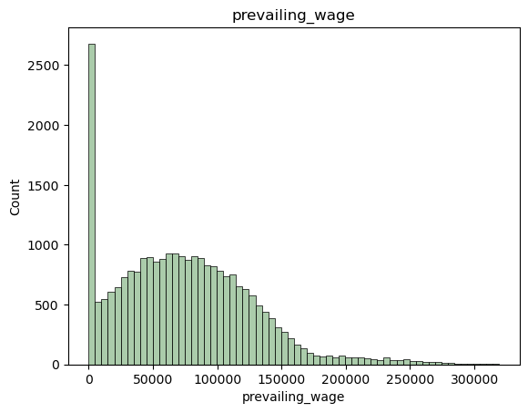

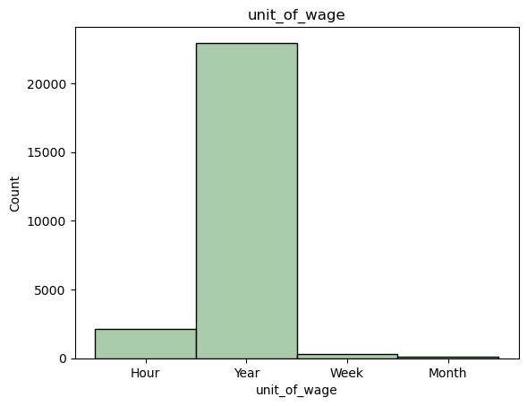

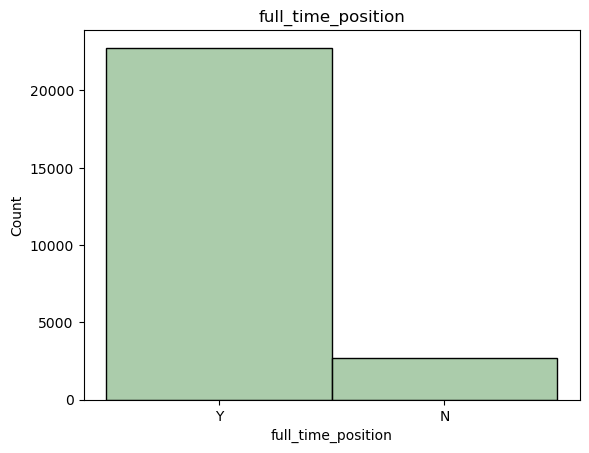

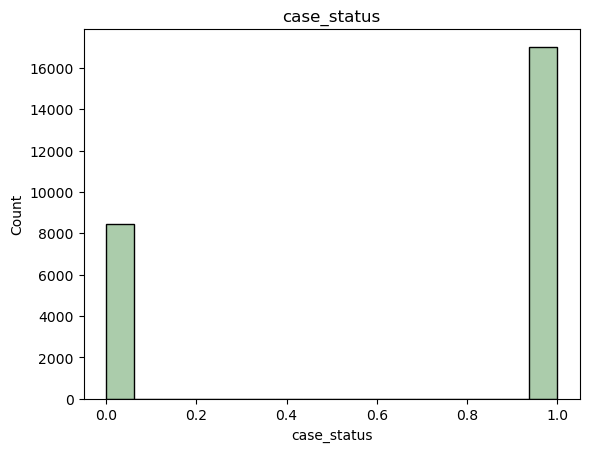

```python
#histogram for each column in visa
#all histograms use data from visa dataframe and the color is set to darkseagreen
for i in visa.columns: #for all columns in visa
    if (i=='continent'): #if the column is continent
        sns.histplot(data=visa, x=i, color='darkseagreen') #make histogram with the column on the x-axis
        plt.title(i) #title is set to column name
        plt.xticks(rotation=90) #x-axis labels are rotated 90 degrees
        plt.show(); #display histogram
    else: #for all other columns
        sns.histplot(data=visa, x=i, color='darkseagreen') #make histogram with the column on x-axis
        plt.title(i) #title is set to column name
        plt.show(); #display histogram
```

#### Observations:

- There no changes in distribution in each column.

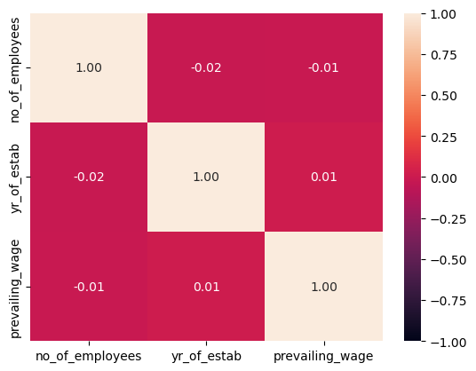

```python
#creating heatmap using visa_num columns to view correlation
#labels are shown/have 2 decimal spaces
#range is from -1 to 1
sns.heatmap(visa_num.corr(), annot=True, vmin=-1, vmax=1, fmt='.2f')
```

#### Observations:

There are no changes in correlation.

## Building/Tuning Models

```python
#confusion matrix and performance metrics functions

#confusion matrix function for training set
def confusion_matrix_train(X_train, y_train): #X_train and y_train are parameters
    """
    Builds and displays confusion matrix for training set with the given X_train and y_train.
    Prediction are calculated through model.
    """
    X_train_pred = model.predict(X_train) #making predictions for X_train using model
    matrix_train = confusion_matrix(y_train, X_train_pred) #building confusion matrix with y_train and X_train_pred
    sns.heatmap(matrix_train, fmt='g', annot=True) #creating heatmap for matrix/annotation labels displayed as full numbers
    plt.title('Confusion matrix - Training Set') #heatmap title
    plt.xlabel('Predicted Values') #x-axis title
    plt.ylabel('Actual Values') #y-axis title
    plt.show(); #displaying heatmap

def confusion_matrix_test(X_test, y_test): #X_test and y_test are parameters
    """
    Builds and displays confusion matrix for testing set with the given X_train and y_train.
    Prediction are calculated through model.
    """
    X_test_pred = model.predict(X_test) #making predictions for X_test using model
    matrix_test = confusion_matrix(y_test, X_test_pred) #building confusion matrix with y_test and X_test_pred
    sns.heatmap(matrix_test, fmt='g', annot=True) #heatmap for matrix/annotation labels displayed as full numbers
    plt.title('Confusion matrix - Testing Set') #heatmap title
    plt.xlabel('Predicted Values') #x-axis title
    plt.ylabel('Actual Values') #y-axis title
    plt.show(); #displaying heatmap

def calculate_metrics(X_train, X_test, y_train, y_test): #X_train, X_test, y_train and y_test are parameters
    """
    Builds a dataframe with accuracy, recall, precision, and F1 score.
    Each metric is calculated with provided X_train, X_test, y_train, and y_test, along with calculated predictions.
    """
    X_train_pred = model.predict(X_train) #making predictions for X_train using model
    X_test_pred = model.predict(X_test) #making predictions for X_test using model
    metrics = pd.DataFrame() #creating dataframe for metrics
    metrics['Group'] = ['Training', 'Testing'] #adding a column to show whether the row is training or testing
    metrics['Accuracy'] = [accuracy_score(y_train, X_train_pred), accuracy_score(y_test, X_test_pred)] #accuracy column
    metrics['Recall'] = [recall_score(y_train, X_train_pred), recall_score(y_test, X_test_pred)] #recall column
    metrics['Precision'] = [precision_score(y_train, X_train_pred), precision_score(y_test, X_test_pred)] #precision column
    metrics['F1'] = [f1_score(y_train, X_train_pred), f1_score(y_test, X_test_pred)] #f1 score column
    return metrics #displaying metrics dataframe

def retrieve_importance(X_train): #X_train is a parameter
    """
    Retrieves the feature importance for all of the columns in X_train.
    Sorts the features by their importance in descending order.
    """
    imp = pd.DataFrame(index=X_train.columns) #creating dataframe for feature importance values where index is the X_train column name
    imp['importance'] = model.feature_importances_ #uses model to gather feature importance values for the importance column
    return imp['importance'].sort_values(ascending=False) #shows dataframe with values in descending order
```

### Decision Tree - Untuned

```python
#using y_train and X_train to build decision tree/gini criterion used to split
model = DecisionTreeClassifier(criterion='gini', random_state=1)
model.fit(X_train, y_train)
```

```
DecisionTreeClassifier(random_state=1)
```

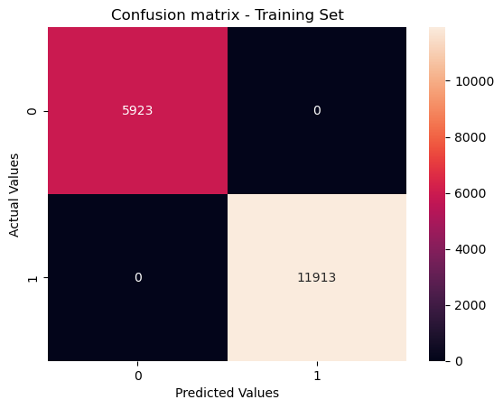

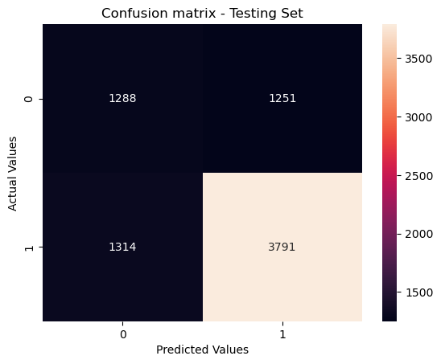

```python
#confusion matrix for training set
confusion_matrix_train(X_train, y_train)
#confusion matrix for testing set
confusion_matrix_test(X_test, y_test)
```

```python
#performance metrics
untuned_tree = calculate_metrics(X_train, X_test, y_train, y_test)
untuned_tree
```

|  | Group | Accuracy | Recall | Precision | F1 |
| --- | --- | --- | --- | --- | --- |
| 0 | Training | 1.000000 | 1.000000 | 1.000000 | 1.000000 |
| 1 | Testing | 0.664443 | 0.742605 | 0.751884 | 0.747216 |

#### Observations:

The decision tree model is overfitting because all of the performance metrics for training equal 1, and the metrics for training and testing are very different.

### Decision Tree - Tuned

```python
#selecting classifier
model = DecisionTreeClassifier(class_weight={0:0.30, 1:0.70}, random_state=1)

#setting options for parameter values
parameters = {'max_depth': np.arange(2,6),
              'min_samples_leaf': [1, 4, 7],
              'max_leaf_nodes' : [10, 15],
              'min_impurity_decrease': [0.0001,0.001]}

#using recall score to compare parameter combinations
score = metrics.make_scorer(recall_score)

#using X_train and y_train for Grid Search/cross-validation is set to 5
search_grid = GridSearchCV(model, parameters, scoring=score, cv=5)
search_grid = search_grid.fit(X_train, y_train)

#model is the best combination of parameters
model = search_grid.best_estimator_
#applying the parameter combination on X_train and y_train
model.fit(X_train, y_train)
```

```
DecisionTreeClassifier(class_weight={0: 0.3, 1: 0.7}, max_depth=3,
                       max_leaf_nodes=10, min_impurity_decrease=0.0001,
                       random_state=1)
```

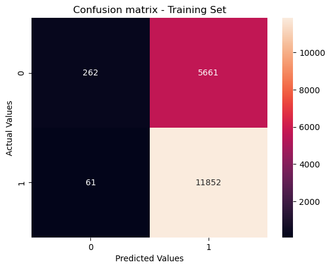

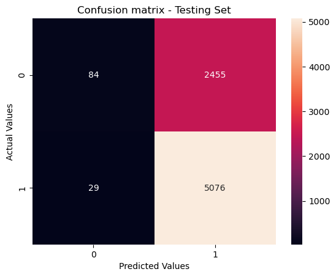

```python
#confusion matrix for training set
confusion_matrix_train(X_train, y_train)
#confusion matrix for testing set
confusion_matrix_test(X_test, y_test)
```

```python
#performance metrics
tuned_tree = calculate_metrics(X_train, X_test, y_train, y_test)
tuned_tree
```

|  | Group | Accuracy | Recall | Precision | F1 |
| --- | --- | --- | --- | --- | --- |
| 0 | Training | 0.679188 | 0.994880 | 0.676754 | 0.805546 |
| 1 | Testing | 0.675039 | 0.994319 | 0.674014 | 0.803419 |

#### Observations:

- There is no overfitting because the metrics for the training and testing set are similar, so the model is able to generalize well to the testing set.
- There is a slight increase in Accuracy, and a decrease in Precision.
- The F1 score and Recall improved.
- The tuned model performs better than the untuned model.

**Feature Importance for Tuned Decision Tree**

```python
#feature importance
retrieve_importance(X_train)
```

```
education_of_employee_High School    0.528078
prevailing_wage                      0.245591
has_job_experience_Y                 0.164966
continent_Asia                       0.033946
region_of_employment_West            0.014456
continent_Europe                     0.012964
no_of_employees                      0.000000
region_of_employment_Midwest         0.000000
unit_of_wage_Year                    0.000000
unit_of_wage_Week                    0.000000
unit_of_wage_Month                   0.000000
region_of_employment_South           0.000000
region_of_employment_Northeast       0.000000
education_of_employee_Master's       0.000000
requires_job_training_Y              0.000000
yr_of_estab                          0.000000
education_of_employee_Doctorate      0.000000
continent_South America              0.000000
continent_Oceania                    0.000000
continent_North America              0.000000
full_time_position_Y                 0.000000
Name: importance, dtype: float64
```

#### Observations:

- The top important feature is the education level of an employee being high school.
- The next four important features are prevailing wage, having job experience, being from Asia, and intending to work in the west region.

### Bagging Classifier - Untuned

```python
#using X_train and y_train to build bagging classifier
model = BaggingClassifier(random_state=1)
model.fit(X_train, y_train)
```

```
BaggingClassifier(random_state=1)
```

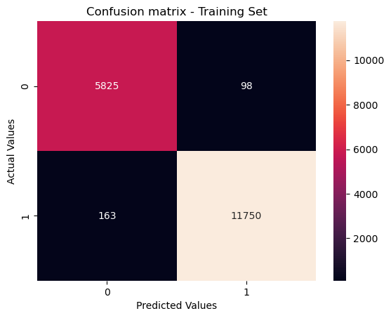

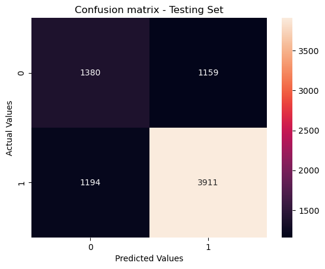

```python
#confusion matrix for training set
confusion_matrix_train(X_train, y_train)
#confusion matrix for testing set
confusion_matrix_test(X_test, y_test)
```

```python
#performance metrics
untuned_bagging = calculate_metrics(X_train, X_test, y_train, y_test)
untuned_bagging
```

|  | Group | Accuracy | Recall | Precision | F1 |
| --- | --- | --- | --- | --- | --- |
| 0 | Training | 0.985367 | 0.986317 | 0.991729 | 0.989016 |
| 1 | Testing | 0.692177 | 0.766112 | 0.771400 | 0.768747 |

#### Observations:

- The model is overfitting because the training metrics are much higher than testing metrics. The model is not able to generalize well to the testing set.

### Bagging Classifier - Tuned

```python
#selecting classifier
model = BaggingClassifier(random_state=1)

#setting options for parameter values
parameters = {'max_samples': [0.8,0.9,1],
              'max_features': [0.7,0.8,0.9],
              'n_estimators' : [30,50,70]}

#using recall score to compare parameter combinations
score = metrics.make_scorer(recall_score)

#using X_train and y_train for Grid Search/cross-validation is set to 5
search_grid = GridSearchCV(model, parameters, scoring=score, cv=5)
search_grid = search_grid.fit(X_train, y_train)

#model is the best combination of parameters
model = search_grid.best_estimator_
#applying the parameter combination on X_train and y_train
model.fit(X_train, y_train)
bagging_model = model #saving the model to a variable for later use
```

```python
#confusion matrix for training set
confusion_matrix_train(X_train, y_train)
#confusion matrix for testing set
confusion_matrix_test(X_test, y_test)
```

[output not shown]

```python
#performance metrics
tuned_bagging = calculate_metrics(X_train, X_test, y_train, y_test)
tuned_bagging
```

|  | Group | Accuracy | Recall | Precision | F1 |
| --- | --- | --- | --- | --- | --- |
| 0 | Training | 0.667919 | 1.0 | 0.667919 | 0.800901 |
| 1 | Testing | 0.667844 | 1.0 | 0.667844 | 0.800847 |

#### Observations:

- The training and testing set have similar metrics, so the model performs consistently on both sets of data.
- Accuracy and Precision decreased.
- F1 score increased to 0.80.
- The Recall increased to 1.0.
- The tuned model performs better than the untuned model.

### Random Forest - Untuned

```python
#using X_train and y_train to build random forest classifier
model = RandomForestClassifier(random_state=1)
model.fit(X_train, y_train)
```

```
RandomForestClassifier(random_state=1)
```

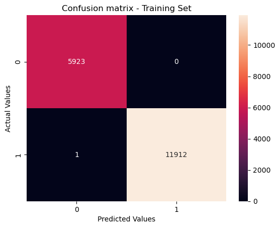

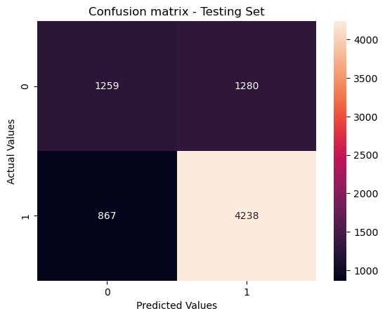

```python
#confusion matrix for training set
confusion_matrix_train(X_train, y_train)
#confusion matrix for testing set
confusion_matrix_test(X_test, y_test)
```

```python
#performance metrics
untuned_forest = calculate_metrics(X_train, X_test, y_train, y_test)
untuned_forest
```

|  | Group | Accuracy | Recall | Precision | F1 |
| --- | --- | --- | --- | --- | --- |
| 0 | Training | 0.999944 | 0.999916 | 1.000000 | 0.999958 |
| 1 | Testing | 0.719126 | 0.830167 | 0.768032 | 0.797891 |

#### Observations:

- The model is overfitting because the training metrics are close to 1, and the metrics for training and testing are very different. The model is not as consistent on the testing set.

### Random Forest - Tuned

```python
#selecting classifier
model = RandomForestClassifier(random_state=1)

#setting options for parameter values
parameters = {'n_estimators': [50,110,25],
              'min_samples_leaf': np.arange(1, 4),
              'max_features': [np.arange(0.3, 0.6, 0.1),'sqrt'],
              'max_samples': np.arange(0.4, 0.7, 0.1)}

#using recall score to compare parameter combinations
score = metrics.make_scorer(recall_score)

#using X_train and y_train for Grid Search/cross-validation is set to 5
search_grid = GridSearchCV(model, parameters, scoring=score, cv=5)
search_grid = search_grid.fit(X_train, y_train)

#model is the best combination of parameters
model = search_grid.best_estimator_
#applying the parameter combination on X_train and y_train
model.fit(X_train, y_train)
```

```
RandomForestClassifier(max_samples=0.4, min_samples_leaf=3, n_estimators=110,
                       random_state=1)
```

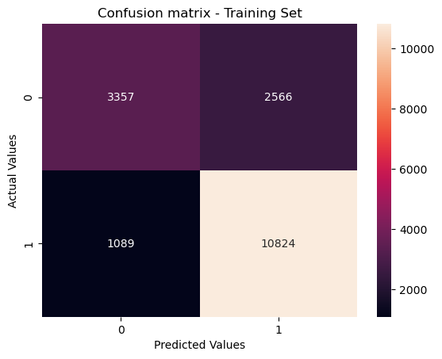

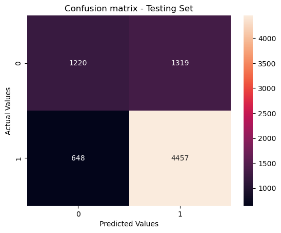

```python
#confusion matrix for training set
confusion_matrix_train(X_train, y_train)
#confusion matrix for testing set
confusion_matrix_test(X_test, y_test)
```

```python
#performance metrics
tuned_forest = calculate_metrics(X_train, X_test, y_train, y_test)
tuned_forest
```

|  | Group | Accuracy | Recall | Precision | F1 |
| --- | --- | --- | --- | --- | --- |
| 0 | Training | 0.795077 | 0.908587 | 0.808364 | 0.855551 |
| 1 | Testing | 0.742674 | 0.873066 | 0.771641 | 0.819226 |

#### Observations:

- The metrics are similar for the training and testing set, but there is still a very small difference. The model might be very slightly overfitting.
- There is only a slight increase in Accuracy, Recall, Precision, and F1 score.
- Compared to the untuned model, the tuned model performs better.

**Feature Importance for Tuned Random Forest**

```python
#feature importance
retrieve_importance(X_train)
```

```
prevailing_wage                      0.208166
no_of_employees                      0.163183
yr_of_estab                          0.140326
education_of_employee_High School    0.132958
has_job_experience_Y                 0.079480
education_of_employee_Master's       0.061212
unit_of_wage_Year                    0.032438
education_of_employee_Doctorate      0.030310
continent_Europe                     0.025823
continent_Asia                       0.016211
region_of_employment_Midwest         0.016134
region_of_employment_West            0.015403
full_time_position_Y                 0.014310
region_of_employment_South           0.014095
requires_job_training_Y              0.013702
continent_North America              0.013545
region_of_employment_Northeast       0.012695
continent_South America              0.006787
continent_Oceania                    0.001415
unit_of_wage_Week                    0.001279
unit_of_wage_Month                   0.000528
Name: importance, dtype: float64
```

#### Observations:

- The top important feature is prevailing wage.
- The next four important features are number of employees, year of establishment, education level of employee being high school, and having job experience.

### AdaBoost - Untuned

```python
#using X_train and y_train to build AdaBoost Classifier
model = AdaBoostClassifier(random_state=1)
model.fit(X_train, y_train)
```

```
AdaBoostClassifier(random_state=1)
```

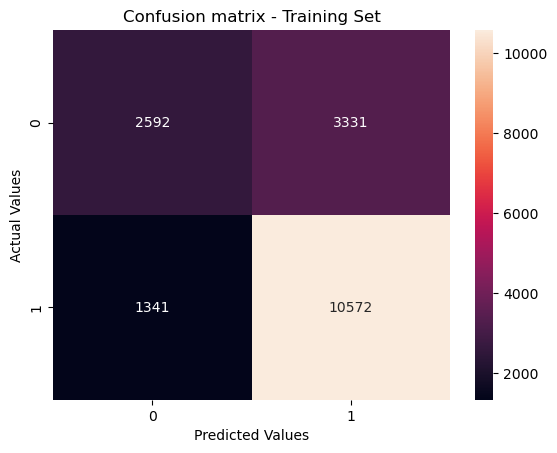

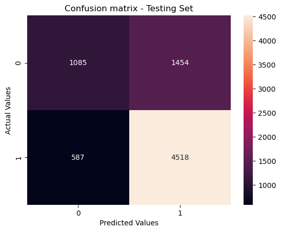

```python
#confusion matrix for training set
confusion_matrix_train(X_train, y_train)
#confusion matrix for testing set
confusion_matrix_test(X_test, y_test)
```

```python
#performance metrics
untuned_AdaBoost = calculate_metrics(X_train, X_test, y_train, y_test)
untuned_AdaBoost
```

|  | Group | Accuracy | Recall | Precision | F1 |
| --- | --- | --- | --- | --- | --- |
| 0 | Training | 0.738058 | 0.887434 | 0.760411 | 0.819027 |
| 1 | Testing | 0.732993 | 0.885015 | 0.756530 | 0.815744 |

#### Observations:

- The model performs consistently on the training set and testing set.

### AdaBoost - Tuned

```python
#selecting classifier
model = AdaBoostClassifier(random_state=1)

#setting options for parameter values
parameters = {'n_estimators': np.arange(50,110,25),
              'learning_rate': [0.01,0.1,0.05],
              'base_estimator': [DecisionTreeClassifier(max_depth=2, random_state=1),
                                 DecisionTreeClassifier(max_depth=3, random_state=1)]}

#using recall score to compare parameter combinations
score = metrics.make_scorer(recall_score)

#using X_train and y_train for Grid Search/cross-validation is set to 5
search_grid = GridSearchCV(model, parameters, scoring=score, cv=5)
search_grid = search_grid.fit(X_train, y_train)

#model is the best combination of parameters
model = search_grid.best_estimator_
#applying the parameter combination on X_train and y_train
model.fit(X_train, y_train)
adaboost_model = model #saving the model to a variable for later use
```

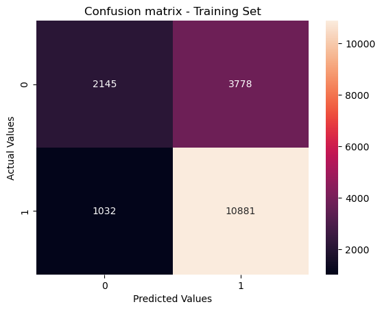

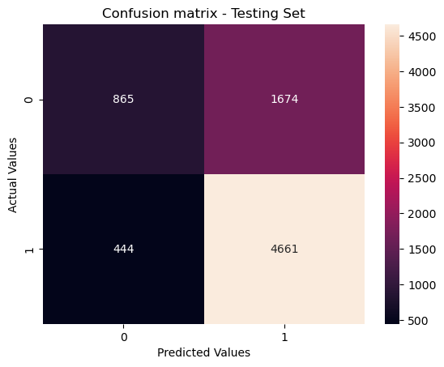

```python
#confusion matrix for training set
confusion_matrix_train(X_train, y_train)
#confusion matrix for testing set
confusion_matrix_test(X_test, y_test)
```

```python
#performance metrics
tuned_AdaBoost = calculate_metrics(X_train, X_test, y_train, y_test)
tuned_AdaBoost
```

|  | Group | Accuracy | Recall | Precision | F1 |
| --- | --- | --- | --- | --- | --- |
| 0 | Training | 0.730321 | 0.913372 | 0.742274 | 0.818982 |
| 1 | Testing | 0.722920 | 0.913026 | 0.735754 | 0.814860 |

#### Observations:

- The testing and training set have similar metrics.
- F1 score mostly remained the same.
- There is a slight decrease in Accuracy and Precision.
- Recall increased to 0.91.
- Compared to the untuned model, the tuned model performs better.

**Feature Importance for Tuned AdaBoost**

```python
#feature importance
retrieve_importance(X_train)
```

```
education_of_employee_High School    0.422785
has_job_experience_Y                 0.208365
prevailing_wage                      0.157466
education_of_employee_Doctorate      0.094939
education_of_employee_Master's       0.093466
continent_Asia                       0.013068
unit_of_wage_Year                    0.006508
continent_North America              0.003403
region_of_employment_Northeast       0.000000
unit_of_wage_Week                    0.000000
unit_of_wage_Month                   0.000000
region_of_employment_West            0.000000
region_of_employment_South           0.000000
no_of_employees                      0.000000
region_of_employment_Midwest         0.000000
requires_job_training_Y              0.000000
yr_of_estab                          0.000000
continent_South America              0.000000
continent_Oceania                    0.000000
continent_Europe                     0.000000
full_time_position_Y                 0.000000
Name: importance, dtype: float64
```

#### Observations:

- The top important feature is the education level of an employee being high school.
- The next four important features are having job experience, prevailing wage, education level of an employee being doctorate, and education level of an employee being master's.

### Gradient Boosting - Untuned

```python
#using X_train and y_train to build Gradient Boosting Classifier
model = GradientBoostingClassifier(random_state=1)
model.fit(X_train, y_train)
```

```
GradientBoostingClassifier(random_state=1)
```

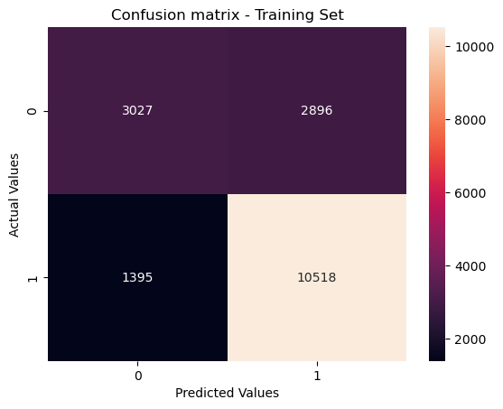

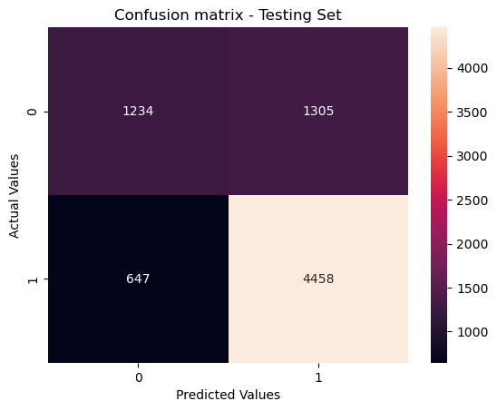

```python
#confusion matrix for training set
confusion_matrix_train(X_train, y_train)
#confusion matrix for testing set
confusion_matrix_test(X_test, y_test)
```

```python
#performance metrics
untuned_gradient = calculate_metrics(X_train, X_test, y_train, y_test)
untuned_gradient
```

|  | Group | Accuracy | Recall | Precision | F1 |
| --- | --- | --- | --- | --- | --- |
| 0 | Training | 0.759419 | 0.882901 | 0.784106 | 0.830576 |
| 1 | Testing | 0.744636 | 0.873262 | 0.773555 | 0.820390 |

#### Observations:

- The models performs consistently on the training set and testing set.

### Gradient Boosting - Tuned

```python
#selecting classifier
model = GradientBoostingClassifier(random_state=1)

#setting options for parameter values
parameters = {'init': [AdaBoostClassifier(random_state=1),DecisionTreeClassifier(random_state=1)],
              'n_estimators': np.arange(50,110,25),
              'learning_rate': [0.01,0.1,0.05],
              'subsample':[0.7,0.9],
              'max_features':[0.5,0.7,1]}

#using recall score to compare parameter combinations
score = metrics.make_scorer(recall_score)

#using X_train and y_train for Grid Search/cross-validation is set to 5
search_grid = GridSearchCV(model, parameters, scoring=score, cv=5)
search_grid = search_grid.fit(X_train, y_train)

#model is the best combination of parameters
model = search_grid.best_estimator_
#applying the parameter combination on X_train and y_train
model.fit(X_train, y_train)
gradient_model = model #saving the model to a variable for later use
```

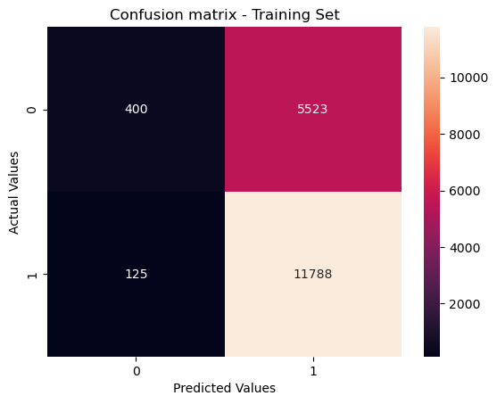

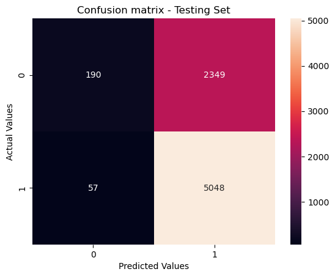

```python
#confusion matrix for training set
confusion_matrix_train(X_train, y_train)
#confusion matrix for testing set
confusion_matrix_test(X_test, y_test)
```

```python
#performance metrics
tuned_gradient = calculate_metrics(X_train, X_test, y_train, y_test)
tuned_gradient
```

|  | Group | Accuracy | Recall | Precision | F1 |
| --- | --- | --- | --- | --- | --- |
| 0 | Training | 0.683337 | 0.989507 | 0.680954 | 0.806734 |
| 1 | Testing | 0.685243 | 0.988834 | 0.682439 | 0.807551 |

#### Observations:

- The training and testing set have similar metrics.
- Accuracy, Precision, and F1 score decreased.
- Compared to the untuned model, the tuned model has a higher Recall.

**Feature Importance for Tuned Gradient Boosting**

```python
#feature importance
retrieve_importance(X_train)
```

```
education_of_employee_High School    0.269333
prevailing_wage                      0.175421
has_job_experience_Y                 0.126229
unit_of_wage_Year                    0.122013
education_of_employee_Master's       0.119280
education_of_employee_Doctorate      0.063218
continent_Europe                     0.034772
region_of_employment_Midwest         0.023599
region_of_employment_West            0.013154
region_of_employment_South           0.010998
continent_North America              0.008594
continent_Asia                       0.008237
no_of_employees                      0.006365
region_of_employment_Northeast       0.005943
yr_of_estab                          0.005796
continent_South America              0.003836
requires_job_training_Y              0.001043
full_time_position_Y                 0.000837
continent_Oceania                    0.000610
unit_of_wage_Week                    0.000461
unit_of_wage_Month                   0.000261
Name: importance, dtype: float64
```

#### Observations:

- The top important feature is the education level of an employee being high school.
- The next four important features are prevailing wage, having job experience, having a yearly unit of wage, and education level of an employee being master's.

### XGBoost - Untuned

```python
#using X_train and y_train to build XGBoost classifier
model = XGBClassifier(random_state=1, eval_metric='logloss')
model.fit(X_train, y_train)
```

```
XGBClassifier(base_score=None, booster=None, callbacks=None,
              colsample_bylevel=None, colsample_bynode=None,
              colsample_bytree=None, device=None, early_stopping_rounds=None,
              enable_categorical=False, eval_metric='logloss',
              feature_types=None, gamma=None, grow_policy=None,
              importance_type=None, interaction_constraints=None,
              learning_rate=None, max_bin=None, max_cat_threshold=None,
              max_cat_to_onehot=None, max_delta_step=None, max_depth=None,
              max_leaves=None, min_child_weight=None, missing=nan,
              monotone_constraints=None, multi_strategy=None, n_estimators=None,
              n_jobs=None, num_parallel_tree=None, random_state=1, ...)
```

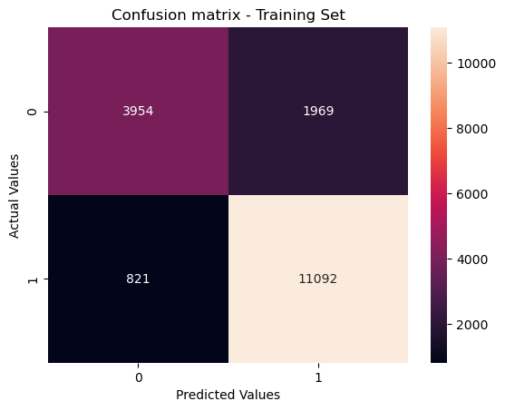

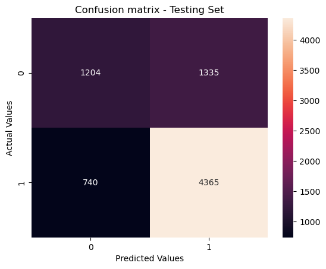

```python
#confusion matrix for training set
confusion_matrix_train(X_train, y_train)
#confusion matrix for testing set
confusion_matrix_test(X_test, y_test)
```

```python
#performance metrics
untuned_XGBoost = calculate_metrics(X_train, X_test, y_train, y_test)
untuned_XGBoost
```

|  | Group | Accuracy | Recall | Precision | F1 |
| --- | --- | --- | --- | --- | --- |
| 0 | Training | 0.843575 | 0.931084 | 0.849246 | 0.888284 |
| 1 | Testing | 0.728545 | 0.855044 | 0.765789 | 0.807959 |

#### Observations:

- The model performs similarly on the training set and testing set, but there is still some overfitting.

### XGBoost - Tuned

```python
#selecting classifier
model = XGBClassifier(random_state=1, eval_metric='logloss')

#setting options for parameter values
parameters = {'n_estimators':np.arange(50,110,25),
              'scale_pos_weight':[1,2,5],
              'learning_rate':[0.01,0.1,0.05],
              'gamma':[1,3],
              'subsample':[0.7,0.9]}

#using recall score to compare parameter combinations
score = metrics.make_scorer(recall_score)

#using X_train and y_train for Grid Search/cross-validation is set to 5
search_grid = GridSearchCV(model, parameters, scoring=score, cv=5)
search_grid = search_grid.fit(X_train, y_train)

#model is the best combination of parameters
model = search_grid.best_estimator_
#applying the parameter combination on X_train and y_train
model.fit(X_train, y_train)
xgb_model = model #saving the model to a variable for later use
```

```python
#confusion matrix for training set
confusion_matrix_train(X_train, y_train)
#confusion matrix for testing set
confusion_matrix_test(X_test, y_test)
```

[output not shown]

```python
#performance metrics
tuned_XGBoost = calculate_metrics(X_train, X_test, y_train, y_test)
tuned_XGBoost
```

|  | Group | Accuracy | Recall | Precision | F1 |
| --- | --- | --- | --- | --- | --- |
| 0 | Training | 0.667919 | 1.0 | 0.667919 | 0.800901 |
| 1 | Testing | 0.667844 | 1.0 | 0.667844 | 0.800847 |

#### Observations:

- The model performs more consistently on the training and testing set, and there is no overfitting.
- Accuracy and Precision decreased, and F1 score remained about the same.
- Recall increased.
- Compared to the untuned model, the tuned model performs more consistently on the training and testing sets. The recall is also higher.

**Feature Importance for Tuned XGBoost**

```python
#feature importance
retrieve_importance(X_train)
```

```
education_of_employee_High School    0.581525
has_job_experience_Y                 0.089743
unit_of_wage_Year                    0.048956
education_of_employee_Master's       0.041290
continent_Europe                     0.036549
region_of_employment_Midwest         0.033450
education_of_employee_Doctorate      0.029145
region_of_employment_South           0.024256
prevailing_wage                      0.023316
continent_Asia                       0.014434
region_of_employment_Northeast       0.014067
region_of_employment_West            0.013556
continent_Oceania                    0.007439
continent_North America              0.007350
full_time_position_Y                 0.006767
unit_of_wage_Week                    0.006560
continent_South America              0.006414
requires_job_training_Y              0.005933
yr_of_estab                          0.004890
no_of_employees                      0.004360
unit_of_wage_Month                   0.000000
Name: importance, dtype: float32
```

#### Observations:

- The top important feature is the education level of an employee being high school.
- The next four important features are having job experience, having a yearly unit of wage, having an education level of master's, and being from europe.

### Stacking Classifier

```python
#selecting estimators for stacking model
estimators = [('Bagging Classifier', bagging_model), ('AdaBoost', adaboost_model), ('Gradient Boosting', gradient_model)]
estimator = xgb_model #selecting final estimator
model = StackingClassifier(estimators=estimators, final_estimator=estimator) #using estimators to build Stacking Classifier
model.fit(X_train, y_train) #fitting X_train and y_train to model
```

```
StackingClassifier(estimators=[('Bagging Classifier',
                                BaggingClassifier(max_features=0.7,
                                                  max_samples=1,
                                                  n_estimators=30,
                                                  random_state=1)),
                               ('AdaBoost',
                                AdaBoostClassifier(base_estimator=DecisionTreeClassifier(max_depth=2,
                                                                                         random_state=1),
                                                   learning_rate=0.01,
                                                   n_estimators=75,
                                                   random_state=1)),
                               ('Gradient Boosting',
                                GradientBoostingClassifier(init=AdaBoostClassif...
                                                 feature_types=None, gamma=1,
                                                 grow_policy=None,
                                                 importance_type=None,
                                                 interaction_constraints=None,
                                                 learning_rate=0.01,
                                                 max_bin=None,
                                                 max_cat_threshold=None,
                                                 max_cat_to_onehot=None,
                                                 max_delta_step=None,
                                                 max_depth=None,
                                                 max_leaves=None,
                                                 min_child_weight=None,
                                                 missing=nan,
                                                 monotone_constraints=None,
                                                 multi_strategy=None,
                                                 n_estimators=50, n_jobs=None,
                                                 num_parallel_tree=None,
                                                 random_state=1, ...))
```

```python
#confusion matrix for training set
confusion_matrix_train(X_train, y_train)
#confusion matrix for testing set
confusion_matrix_test(X_test, y_test)
```

[output not shown]

```python
#performance metrics
stacking_model = calculate_metrics(X_train, X_test, y_train, y_test)
stacking_model
```

|  | Group | Accuracy | Recall | Precision | F1 |
| --- | --- | --- | --- | --- | --- |
| 0 | Training | 0.667919 | 1.0 | 0.667919 | 0.800901 |
| 1 | Testing | 0.667844 | 1.0 | 0.667844 | 0.800847 |

#### Observations:

- The training and testing set have similar metrics, so the model generalizes well to the testing set.
- The F1 score is decent around 0.80.
- The Recall is also perfect.

## Model Performance Comparison and Conclusions

**Decision Tree - Tuned**

```python
#displaying performance metrics for tuned decision tree
tuned_tree
```

|  | Group | Accuracy | Recall | Precision | F1 |
| --- | --- | --- | --- | --- | --- |
| 0 | Training | 0.679188 | 0.994880 | 0.676754 | 0.805546 |
| 1 | Testing | 0.675039 | 0.994319 | 0.674014 | 0.803419 |

**Bagging Classifier - Tuned**

```python
#displaying performance metrics for tuned bagging classifier
tuned_bagging
```

|  | Group | Accuracy | Recall | Precision | F1 |
| --- | --- | --- | --- | --- | --- |
| 0 | Training | 0.667919 | 1.0 | 0.667919 | 0.800901 |
| 1 | Testing | 0.667844 | 1.0 | 0.667844 | 0.800847 |

**Random Forest - Tuned**

```python
#displaying performance metrics for tuned random forest
tuned_forest
```

|  | Group | Accuracy | Recall | Precision | F1 |
| --- | --- | --- | --- | --- | --- |
| 0 | Training | 0.795077 | 0.908587 | 0.808364 | 0.855551 |
| 1 | Testing | 0.742674 | 0.873066 | 0.771641 | 0.819226 |

**AdaBoost - Tuned**

```python
#displaying performance metrics for tuned AdaBoost model
tuned_AdaBoost
```

|  | Group | Accuracy | Recall | Precision | F1 |
| --- | --- | --- | --- | --- | --- |
| 0 | Training | 0.730321 | 0.913372 | 0.742274 | 0.818982 |
| 1 | Testing | 0.722920 | 0.913026 | 0.735754 | 0.814860 |

**Gradient Boosting - Tuned**

```python
#displaying performance metrics for gradient boosting model
tuned_gradient
```

|  | Group | Accuracy | Recall | Precision | F1 |
| --- | --- | --- | --- | --- | --- |
| 0 | Training | 0.683337 | 0.989507 | 0.680954 | 0.806734 |
| 1 | Testing | 0.685243 | 0.988834 | 0.682439 | 0.807551 |

**XGBoost - Tuned**

```python
#displaying performance metrics for XGBoost model
tuned_XGBoost
```

|  | Group | Accuracy | Recall | Precision | F1 |
| --- | --- | --- | --- | --- | --- |
| 0 | Training | 0.667919 | 1.0 | 0.667919 | 0.800901 |
| 1 | Testing | 0.667844 | 1.0 | 0.667844 | 0.800847 |

**Stacking Model**

```python
#displaying performance metrics for stacking model
stacking_model
```

|  | Group | Accuracy | Recall | Precision | F1 |
| --- | --- | --- | --- | --- | --- |
| 0 | Training | 0.667919 | 1.0 | 0.667919 | 0.800901 |
| 1 | Testing | 0.667844 | 1.0 | 0.667844 | 0.800847 |

**Comparisons**

**With a Recall of 1.0, the best performing models have been narrowed down to the Tuned Bagging Classifier, the Tuned XGBoost Model, and the Stacking Model. They all have an F1 score around 0.80.**

It is important to identify more employees who fit the profile for being certified. If a strong candidate is incorrectly identified as not fitting the profile, it will result in a loss of a talented individual. In order to be competetive, it is important to identify many strong candidates, and not incorrectly classify them as not strong. Therefore, Recall is more important.

## Actionable Insights and Recommendations

There will be lower chances of getting a visa certified if:

- Education level is only high school
- Prevailing wage is 0
- Unit of wage is hourly

There will be higher chances of getting a visa certified if:

- Prevailing wage is greater than 0
- Candidate has job experience
- Unit of wage is yearly
- Education is bachelor's, master's, or doctorate (Higher education levels will have higher chances of visa certification)

Further Insights and Recommendations:

- It is out of an applicant's control where they are from, but for the applications from Europe, there are a higher proportion that are certified compared to other continents. For the applications in South America or Oceania, the proportion of applications that are certified are smaller when compared to other continents.
- For applications where the employees intend to work in the midwest or south region, a high proportion are certified compared to other regions of employment.
- Asia has a very high number of applicants. There are less applications from the other continents. Encouraging or motivating applicants from other continents to apply can increase applications from other continents.
- Encouraging more applicants who have completed doctorate to apply can increase competition.